# Risk Factor Analysis

## Outcome Variable

**Outcome Variable:** whz

## Predictor Variables

**Intervention Variable:** parity

**Adjustment Set:**

- arm
- W_mage
- meducyrs
- feducyrs
- hhwealth_quart
- W_mhtcm
- vagbrth
- W_nrooms
- impsan
- delta_W_mage
- delta_meducyrs
- delta_feducyrs
- delta_hhwealth_quart
- delta_W_mhtcm
- delta_vagbrth
- delta_W_nrooms
- delta_impsan

## Stratifying Variables

The analysis was stratified on these variable(s):

- agecat
- studyid
- country

## Data Summary

| agecat | studyid | country | parity | n_cell | n |
| --- | --- | --- | --- | --- | --- |
| Birth | ki1000304b-SAS-CompFeed | INDIA | 1 | 41 | 166 |
| Birth | ki1000304b-SAS-CompFeed | INDIA | 2 | 44 | 166 |
| Birth | ki1000304b-SAS-CompFeed | INDIA | 3+ | 81 | 166 |
| Birth | ki1101329-Keneba | GAMBIA | 1 | 142 | 1292 |
| Birth | ki1101329-Keneba | GAMBIA | 2 | 133 | 1292 |
| Birth | ki1101329-Keneba | GAMBIA | 3+ | 1017 | 1292 |
| Birth | ki1126311-ZVITAMBO | ZIMBABWE | 1 | 5561 | 12915 |
| Birth | ki1126311-ZVITAMBO | ZIMBABWE | 2 | 3882 | 12915 |
| Birth | ki1126311-ZVITAMBO | ZIMBABWE | 3+ | 3472 | 12915 |
| Birth | ki1135781-COHORTS | GUATEMALA | 1 | 94 | 756 |
| Birth | ki1135781-COHORTS | GUATEMALA | 2 | 118 | 756 |
| Birth | ki1135781-COHORTS | GUATEMALA | 3+ | 544 | 756 |
| Birth | ki1135781-COHORTS | INDIA | 1 | 641 | 3855 |
| Birth | ki1135781-COHORTS | INDIA | 2 | 982 | 3855 |
| Birth | ki1135781-COHORTS | INDIA | 3+ | 2232 | 3855 |
| Birth | ki1135781-COHORTS | PHILIPPINES | 1 | 640 | 2899 |
| Birth | ki1135781-COHORTS | PHILIPPINES | 2 | 657 | 2899 |
| Birth | ki1135781-COHORTS | PHILIPPINES | 3+ | 1602 | 2899 |
| Birth | kiGH5241-JiVitA-3 | BANGLADESH | 1 | 4604 | 15692 |
| Birth | kiGH5241-JiVitA-3 | BANGLADESH | 2 | 5539 | 15692 |
| Birth | kiGH5241-JiVitA-3 | BANGLADESH | 3+ | 5549 | 15692 |
| 6 months | ki1000304b-SAS-CompFeed | INDIA | 1 | 392 | 1334 |
| 6 months | ki1000304b-SAS-CompFeed | INDIA | 2 | 302 | 1334 |
| 6 months | ki1000304b-SAS-CompFeed | INDIA | 3+ | 640 | 1334 |
| 6 months | ki1000304b-SAS-FoodSuppl | INDIA | 1 | 72 | 373 |
| 6 months | ki1000304b-SAS-FoodSuppl | INDIA | 2 | 84 | 373 |
| 6 months | ki1000304b-SAS-FoodSuppl | INDIA | 3+ | 217 | 373 |
| 6 months | ki1017093b-PROVIDE | BANGLADESH | 1 | 211 | 582 |
| 6 months | ki1017093b-PROVIDE | BANGLADESH | 2 | 212 | 582 |
| 6 months | ki1017093b-PROVIDE | BANGLADESH | 3+ | 159 | 582 |

[output cut: 51 more lines]

The following strata were considered:

- agecat: 24 months, studyid: ki1017093b-PROVIDE, country: BANGLADESH
- agecat: 24 months, studyid: ki1066203-TanzaniaChild2, country: TANZANIA, UNITED REPUBLIC OF
- agecat: 24 months, studyid: ki1101329-Keneba, country: GAMBIA
- agecat: 24 months, studyid: ki1113344-GMS-Nepal, country: NEPAL
- agecat: 24 months, studyid: ki1126311-ZVITAMBO, country: ZIMBABWE
- agecat: 24 months, studyid: ki1135781-COHORTS, country: GUATEMALA
- agecat: 24 months, studyid: ki1135781-COHORTS, country: INDIA
- agecat: 24 months, studyid: ki1135781-COHORTS, country: PHILIPPINES
- agecat: 24 months, studyid: kiGH5241-JiVitA-3, country: BANGLADESH
- agecat: 6 months, studyid: ki1000304b-SAS-CompFeed, country: INDIA
- agecat: 6 months, studyid: ki1000304b-SAS-FoodSuppl, country: INDIA
- agecat: 6 months, studyid: ki1017093b-PROVIDE, country: BANGLADESH
- agecat: 6 months, studyid: ki1066203-TanzaniaChild2, country: TANZANIA, UNITED REPUBLIC OF
- agecat: 6 months, studyid: ki1101329-Keneba, country: GAMBIA
- agecat: 6 months, studyid: ki1113344-GMS-Nepal, country: NEPAL
- agecat: 6 months, studyid: ki1126311-ZVITAMBO, country: ZIMBABWE
- agecat: 6 months, studyid: ki1135781-COHORTS, country: GUATEMALA
- agecat: 6 months, studyid: ki1135781-COHORTS, country: INDIA
- agecat: 6 months, studyid: ki1135781-COHORTS, country: PHILIPPINES
- agecat: 6 months, studyid: kiGH5241-JiVitA-3, country: BANGLADESH
- agecat: Birth, studyid: ki1000304b-SAS-CompFeed, country: INDIA
- agecat: Birth, studyid: ki1101329-Keneba, country: GAMBIA
- agecat: Birth, studyid: ki1126311-ZVITAMBO, country: ZIMBABWE
- agecat: Birth, studyid: ki1135781-COHORTS, country: GUATEMALA
- agecat: Birth, studyid: ki1135781-COHORTS, country: INDIA
- agecat: Birth, studyid: ki1135781-COHORTS, country: PHILIPPINES
- agecat: Birth, studyid: kiGH5241-JiVitA-3, country: BANGLADESH

### Dropped Strata

Some strata were dropped due to rare outcomes:

- agecat: 24 months, studyid: ki1066203-TanzaniaChild2, country: TANZANIA, UNITED REPUBLIC OF

## Methods Detail

We’re interested in the causal parameters $E[Y_a]$ for all values of $a \in \mathcal{A}$. These parameters represent the mean outcome if, possibly contrary to fact, we intervened to set all units to have $A=a$. Under the randomization and positivity assumptions, these are identified by the statistical parameters $\psi_a=E_W[E_{Y|A,W}(Y|A=a,W)]$. In addition, we’re interested in the mean of $Y$, $E[Y]$ under no intervention (the observed mean). We will estimate these parameters by using SuperLearner to fit the relevant likelihood factors – $E_{Y|A,W}(Y|A=a,W)$ and $p(A=a|W)$, and then updating our likelihood fit using a joint TMLE.

For unadjusted analyses ($W=\{\}$), initial likelihoods were estimated using Lrnr_glm to estimate the simple $E(Y|A)$ and Lrnr_mean to estimate $p(A)$. For adjusted analyses, a small library containing Lrnr_glmnet, Lrnr_xgboost, and Lrnr_mean was used.

Having estimated these parameters, we will then use the delta method to estimate relative risks and attributable risks relative to a prespecified baseline level of $A$.

# Results Detail

## Results Plots

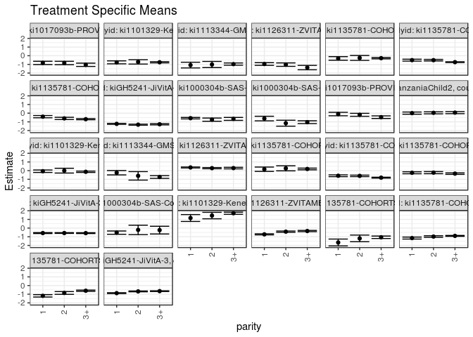

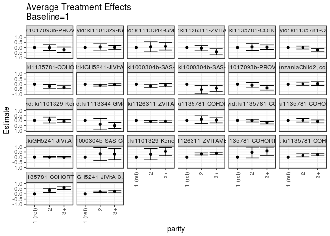

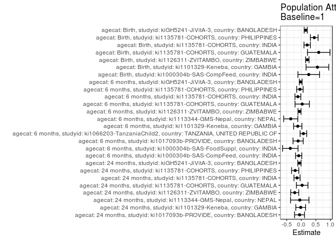

## Results Table

### Parameter: TSM

| agecat | studyid | country | intervention_level | baseline_level | estimate | ci_lower | ci_upper |
| --- | --- | --- | --- | --- | --- | --- | --- |
| Birth | ki1000304b-SAS-CompFeed | INDIA | 1 | NA | -0.5255776 | -0.7158682 | -0.3352869 |
| Birth | ki1000304b-SAS-CompFeed | INDIA | 2 | NA | -0.2089960 | -0.7523617 | 0.3343696 |
| Birth | ki1000304b-SAS-CompFeed | INDIA | 3+ | NA | -0.2349449 | -0.6802631 | 0.2103732 |
| Birth | ki1101329-Keneba | GAMBIA | 1 | NA | 1.1597179 | 0.7632766 | 1.5561592 |
| Birth | ki1101329-Keneba | GAMBIA | 2 | NA | 1.4427745 | 1.0702173 | 1.8153318 |
| Birth | ki1101329-Keneba | GAMBIA | 3+ | NA | 1.7132683 | 1.5909491 | 1.8355875 |
| Birth | ki1126311-ZVITAMBO | ZIMBABWE | 1 | NA | -0.7223571 | -0.7865111 | -0.6582032 |
| Birth | ki1126311-ZVITAMBO | ZIMBABWE | 2 | NA | -0.4126715 | -0.4879044 | -0.3374386 |
| Birth | ki1126311-ZVITAMBO | ZIMBABWE | 3+ | NA | -0.3403790 | -0.4146855 | -0.2660725 |
| Birth | ki1135781-COHORTS | GUATEMALA | 1 | NA | -1.6610174 | -2.0545041 | -1.2675307 |
| Birth | ki1135781-COHORTS | GUATEMALA | 2 | NA | -1.1893668 | -1.5726500 | -0.8060837 |
| Birth | ki1135781-COHORTS | GUATEMALA | 3+ | NA | -1.0607042 | -1.2029272 | -0.9184813 |
| Birth | ki1135781-COHORTS | INDIA | 1 | NA | -1.1518725 | -1.2666499 | -1.0370951 |
| Birth | ki1135781-COHORTS | INDIA | 2 | NA | -0.9788114 | -1.0726125 | -0.8850102 |
| Birth | ki1135781-COHORTS | INDIA | 3+ | NA | -0.8988593 | -0.9526334 | -0.8450852 |
| Birth | ki1135781-COHORTS | PHILIPPINES | 1 | NA | -1.1875367 | -1.3256028 | -1.0494707 |
| Birth | ki1135781-COHORTS | PHILIPPINES | 2 | NA | -0.8549044 | -1.0140053 | -0.6958036 |
| Birth | ki1135781-COHORTS | PHILIPPINES | 3+ | NA | -0.5989802 | -0.6731405 | -0.5248199 |
| Birth | kiGH5241-JiVitA-3 | BANGLADESH | 1 | NA | -0.8766976 | -0.9314893 | -0.8219059 |
| Birth | kiGH5241-JiVitA-3 | BANGLADESH | 2 | NA | -0.6764324 | -0.7246319 | -0.6282328 |
| Birth | kiGH5241-JiVitA-3 | BANGLADESH | 3+ | NA | -0.6461401 | -0.6888123 | -0.6034678 |
| 6 months | ki1000304b-SAS-CompFeed | INDIA | 1 | NA | -0.5769001 | -0.6620224 | -0.4917779 |
| 6 months | ki1000304b-SAS-CompFeed | INDIA | 2 | NA | -0.7470500 | -0.9321324 | -0.5619677 |
| 6 months | ki1000304b-SAS-CompFeed | INDIA | 3+ | NA | -0.6619800 | -0.8319908 | -0.4919691 |
| 6 months | ki1000304b-SAS-FoodSuppl | INDIA | 1 | NA | -0.6184516 | -0.8810703 | -0.3558329 |
| 6 months | ki1000304b-SAS-FoodSuppl | INDIA | 2 | NA | -1.1569840 | -1.4998640 | -0.8141039 |
| 6 months | ki1000304b-SAS-FoodSuppl | INDIA | 3+ | NA | -1.0374886 | -1.2006045 | -0.8743727 |
| 6 months | ki1017093b-PROVIDE | BANGLADESH | 1 | NA | -0.0995789 | -0.2990167 | 0.0998589 |
| 6 months | ki1017093b-PROVIDE | BANGLADESH | 2 | NA | -0.1893913 | -0.3593111 | -0.0194714 |
| 6 months | ki1017093b-PROVIDE | BANGLADESH | 3+ | NA | -0.4597049 | -0.6096016 | -0.3098082 |
| 6 months | ki1066203-TanzaniaChild2 | TANZANIA, UNITED REPUBLIC OF | 1 | NA | 0.0065886 | -0.1203024 | 0.1334795 |
| 6 months | ki1066203-TanzaniaChild2 | TANZANIA, UNITED REPUBLIC OF | 2 | NA | 0.0404974 | -0.0793988 | 0.1603936 |
| 6 months | ki1066203-TanzaniaChild2 | TANZANIA, UNITED REPUBLIC OF | 3+ | NA | 0.0646606 | -0.0571464 | 0.1864675 |
| 6 months | ki1101329-Keneba | GAMBIA | 1 | NA | -0.0667068 | -0.2072197 | 0.0738061 |
| 6 months | ki1101329-Keneba | GAMBIA | 2 | NA | -0.0024632 | -0.2778042 | 0.2728777 |
| 6 months | ki1101329-Keneba | GAMBIA | 3+ | NA | -0.1331764 | -0.2123607 | -0.0539921 |
| 6 months | ki1113344-GMS-Nepal | NEPAL | 1 | NA | -0.2433053 | -0.4942685 | 0.0076579 |
| 6 months | ki1113344-GMS-Nepal | NEPAL | 2 | NA | -0.6020070 | -1.0915310 | -0.1124830 |
| 6 months | ki1113344-GMS-Nepal | NEPAL | 3+ | NA | -0.7344026 | -0.8917611 | -0.5770441 |
| 6 months | ki1126311-ZVITAMBO | ZIMBABWE | 1 | NA | 0.3651814 | 0.3083167 | 0.4220461 |
| 6 months | ki1126311-ZVITAMBO | ZIMBABWE | 2 | NA | 0.2859743 | 0.2176494 | 0.3542992 |
| 6 months | ki1126311-ZVITAMBO | ZIMBABWE | 3+ | NA | 0.2937178 | 0.2053393 | 0.3820964 |
| 6 months | ki1135781-COHORTS | GUATEMALA | 1 | NA | 0.1621961 | -0.0891966 | 0.4135888 |
| 6 months | ki1135781-COHORTS | GUATEMALA | 2 | NA | 0.2668562 | -0.0250645 | 0.5587769 |
| 6 months | ki1135781-COHORTS | GUATEMALA | 3+ | NA | 0.1910083 | 0.0935965 | 0.2884201 |
| 6 months | ki1135781-COHORTS | INDIA | 1 | NA | -0.5894155 | -0.6937671 | -0.4850638 |
| 6 months | ki1135781-COHORTS | INDIA | 2 | NA | -0.6047949 | -0.6909418 | -0.5186480 |
| 6 months | ki1135781-COHORTS | INDIA | 3+ | NA | -0.8103139 | -0.8625716 | -0.7580563 |
| 6 months | ki1135781-COHORTS | PHILIPPINES | 1 | NA | -0.2466430 | -0.3615402 | -0.1317457 |
| 6 months | ki1135781-COHORTS | PHILIPPINES | 2 | NA | -0.2327099 | -0.3542461 | -0.1111736 |
| 6 months | ki1135781-COHORTS | PHILIPPINES | 3+ | NA | -0.3421208 | -0.4288715 | -0.2553700 |
| 6 months | kiGH5241-JiVitA-3 | BANGLADESH | 1 | NA | -0.5739777 | -0.6269323 | -0.5210231 |
| 6 months | kiGH5241-JiVitA-3 | BANGLADESH | 2 | NA | -0.5716045 | -0.6129691 | -0.5302399 |
| 6 months | kiGH5241-JiVitA-3 | BANGLADESH | 3+ | NA | -0.5801790 | -0.6258444 | -0.5345136 |
| 24 months | ki1017093b-PROVIDE | BANGLADESH | 1 | NA | -0.8286845 | -1.0170976 | -0.6402714 |
| 24 months | ki1017093b-PROVIDE | BANGLADESH | 2 | NA | -0.8378507 | -1.0334900 | -0.6422114 |
| 24 months | ki1017093b-PROVIDE | BANGLADESH | 3+ | NA | -1.0463321 | -1.2365309 | -0.8561333 |
| 24 months | ki1101329-Keneba | GAMBIA | 1 | NA | -0.7634819 | -0.9326274 | -0.5943365 |
| 24 months | ki1101329-Keneba | GAMBIA | 2 | NA | -0.7095422 | -0.9598055 | -0.4592789 |
| 24 months | ki1101329-Keneba | GAMBIA | 3+ | NA | -0.7543046 | -0.8244149 | -0.6841943 |
| 24 months | ki1113344-GMS-Nepal | NEPAL | 1 | NA | -1.0793998 | -1.4093806 | -0.7494190 |
| 24 months | ki1113344-GMS-Nepal | NEPAL | 2 | NA | -1.0127595 | -1.3681371 | -0.6573818 |
| 24 months | ki1113344-GMS-Nepal | NEPAL | 3+ | NA | -0.9670169 | -1.0958248 | -0.8382090 |
| 24 months | ki1126311-ZVITAMBO | ZIMBABWE | 1 | NA | -0.9548886 | -1.1089439 | -0.8008333 |
| 24 months | ki1126311-ZVITAMBO | ZIMBABWE | 2 | NA | -1.0268523 | -1.2257271 | -0.8279776 |
| 24 months | ki1126311-ZVITAMBO | ZIMBABWE | 3+ | NA | -1.3679639 | -1.6202626 | -1.1156653 |
| 24 months | ki1135781-COHORTS | GUATEMALA | 1 | NA | -0.3107628 | -0.5154808 | -0.1060448 |
| 24 months | ki1135781-COHORTS | GUATEMALA | 2 | NA | -0.2515877 | -0.5326784 | 0.0295029 |
| 24 months | ki1135781-COHORTS | GUATEMALA | 3+ | NA | -0.2802901 | -0.3579976 | -0.2025826 |
| 24 months | ki1135781-COHORTS | INDIA | 1 | NA | -0.5103737 | -0.6202996 | -0.4004477 |
| 24 months | ki1135781-COHORTS | INDIA | 2 | NA | -0.5121154 | -0.6024175 | -0.4218132 |
| 24 months | ki1135781-COHORTS | INDIA | 3+ | NA | -0.7422043 | -0.7923940 | -0.6920147 |
| 24 months | ki1135781-COHORTS | PHILIPPINES | 1 | NA | -0.4013563 | -0.5301830 | -0.2725297 |
| 24 months | ki1135781-COHORTS | PHILIPPINES | 2 | NA | -0.6035118 | -0.7324888 | -0.4745348 |
| 24 months | ki1135781-COHORTS | PHILIPPINES | 3+ | NA | -0.6921060 | -0.7587600 | -0.6254520 |
| 24 months | kiGH5241-JiVitA-3 | BANGLADESH | 1 | NA | -1.2341399 | -1.2949135 | -1.1733662 |
| 24 months | kiGH5241-JiVitA-3 | BANGLADESH | 2 | NA | -1.3246884 | -1.3850605 | -1.2643163 |
| 24 months | kiGH5241-JiVitA-3 | BANGLADESH | 3+ | NA | -1.2789502 | -1.3509068 | -1.2069937 |

### Parameter: E(Y)

| agecat | studyid | country | intervention_level | baseline_level | estimate | ci_lower | ci_upper |
| --- | --- | --- | --- | --- | --- | --- | --- |
| Birth | ki1000304b-SAS-CompFeed | INDIA | NA | NA | -0.2697590 | -0.5399211 | 0.0004030 |
| Birth | ki1101329-Keneba | GAMBIA | NA | NA | 1.7138545 | 1.6262621 | 1.8014469 |
| Birth | ki1126311-ZVITAMBO | ZIMBABWE | NA | NA | -0.5152877 | -0.5411394 | -0.4894359 |
| Birth | ki1135781-COHORTS | GUATEMALA | NA | NA | -1.0621429 | -1.1631387 | -0.9611471 |
| Birth | ki1135781-COHORTS | INDIA | NA | NA | -0.9498080 | -0.9874148 | -0.9122013 |
| Birth | ki1135781-COHORTS | PHILIPPINES | NA | NA | -0.7427251 | -0.7890855 | -0.6963647 |
| Birth | kiGH5241-JiVitA-3 | BANGLADESH | NA | NA | -0.7238886 | -0.7437224 | -0.7040548 |
| 6 months | ki1000304b-SAS-CompFeed | INDIA | NA | NA | -0.6657084 | -0.8024377 | -0.5289791 |
| 6 months | ki1000304b-SAS-FoodSuppl | INDIA | NA | NA | -0.9946381 | -1.1114079 | -0.8778682 |
| 6 months | ki1017093b-PROVIDE | BANGLADESH | NA | NA | -0.2083706 | -0.2927992 | -0.1239419 |
| 6 months | ki1066203-TanzaniaChild2 | TANZANIA, UNITED REPUBLIC OF | NA | NA | 0.0797179 | 0.0266621 | 0.1327737 |
| 6 months | ki1101329-Keneba | GAMBIA | NA | NA | -0.1874118 | -0.2456850 | -0.1291387 |
| 6 months | ki1113344-GMS-Nepal | NEPAL | NA | NA | -0.6047987 | -0.6909649 | -0.5186325 |
| 6 months | ki1126311-ZVITAMBO | ZIMBABWE | NA | NA | 0.3048076 | 0.2787350 | 0.3308802 |
| 6 months | ki1135781-COHORTS | GUATEMALA | NA | NA | 0.1940810 | 0.1226351 | 0.2655269 |
| 6 months | ki1135781-COHORTS | INDIA | NA | NA | -0.7068611 | -0.7417800 | -0.6719423 |
| 6 months | ki1135781-COHORTS | PHILIPPINES | NA | NA | -0.2938433 | -0.3352064 | -0.2524802 |
| 6 months | kiGH5241-JiVitA-3 | BANGLADESH | NA | NA | -0.5932502 | -0.6127743 | -0.5737261 |
| 24 months | ki1017093b-PROVIDE | BANGLADESH | NA | NA | -0.8879412 | -0.9708680 | -0.8050144 |
| 24 months | ki1101329-Keneba | GAMBIA | NA | NA | -0.7834078 | -0.8357743 | -0.7310414 |
| 24 months | ki1113344-GMS-Nepal | NEPAL | NA | NA | -1.1315863 | -1.2192240 | -1.0439487 |
| 24 months | ki1126311-ZVITAMBO | ZIMBABWE | NA | NA | -1.1802133 | -1.2803837 | -1.0800428 |
| 24 months | ki1135781-COHORTS | GUATEMALA | NA | NA | -0.2813755 | -0.3354674 | -0.2272835 |
| 24 months | ki1135781-COHORTS | INDIA | NA | NA | -0.6564729 | -0.6914450 | -0.6215007 |
| 24 months | ki1135781-COHORTS | PHILIPPINES | NA | NA | -0.6099592 | -0.6467541 | -0.5731643 |
| 24 months | kiGH5241-JiVitA-3 | BANGLADESH | NA | NA | -1.2971774 | -1.3204904 | -1.2738644 |

### Parameter: ATE

| agecat | studyid | country | intervention_level | baseline_level | estimate | ci_lower | ci_upper |
| --- | --- | --- | --- | --- | --- | --- | --- |
| Birth | ki1000304b-SAS-CompFeed | INDIA | 1 | 1 | 0.0000000 | 0.0000000 | 0.0000000 |
| Birth | ki1000304b-SAS-CompFeed | INDIA | 2 | 1 | 0.3165816 | -0.3368058 | 0.9699690 |
| Birth | ki1000304b-SAS-CompFeed | INDIA | 3+ | 1 | 0.2906326 | -0.2461349 | 0.8274002 |
| Birth | ki1101329-Keneba | GAMBIA | 1 | 1 | 0.0000000 | 0.0000000 | 0.0000000 |
| Birth | ki1101329-Keneba | GAMBIA | 2 | 1 | 0.2830566 | -0.2599867 | 0.8261000 |
| Birth | ki1101329-Keneba | GAMBIA | 3+ | 1 | 0.5535504 | 0.1388355 | 0.9682654 |
| Birth | ki1126311-ZVITAMBO | ZIMBABWE | 1 | 1 | 0.0000000 | 0.0000000 | 0.0000000 |
| Birth | ki1126311-ZVITAMBO | ZIMBABWE | 2 | 1 | 0.3096857 | 0.2108363 | 0.4085350 |
| Birth | ki1126311-ZVITAMBO | ZIMBABWE | 3+ | 1 | 0.3819781 | 0.2838195 | 0.4801368 |
| Birth | ki1135781-COHORTS | GUATEMALA | 1 | 1 | 0.0000000 | 0.0000000 | 0.0000000 |
| Birth | ki1135781-COHORTS | GUATEMALA | 2 | 1 | 0.4716505 | -0.0771053 | 1.0204064 |
| Birth | ki1135781-COHORTS | GUATEMALA | 3+ | 1 | 0.6003131 | 0.1815205 | 1.0191057 |
| Birth | ki1135781-COHORTS | INDIA | 1 | 1 | 0.0000000 | 0.0000000 | 0.0000000 |
| Birth | ki1135781-COHORTS | INDIA | 2 | 1 | 0.1730611 | 0.0247077 | 0.3214145 |
| Birth | ki1135781-COHORTS | INDIA | 3+ | 1 | 0.2530132 | 0.1261861 | 0.3798403 |
| Birth | ki1135781-COHORTS | PHILIPPINES | 1 | 1 | 0.0000000 | 0.0000000 | 0.0000000 |
| Birth | ki1135781-COHORTS | PHILIPPINES | 2 | 1 | 0.3326323 | 0.1220164 | 0.5432482 |
| Birth | ki1135781-COHORTS | PHILIPPINES | 3+ | 1 | 0.5885565 | 0.4316278 | 0.7454852 |
| Birth | kiGH5241-JiVitA-3 | BANGLADESH | 1 | 1 | 0.0000000 | 0.0000000 | 0.0000000 |
| Birth | kiGH5241-JiVitA-3 | BANGLADESH | 2 | 1 | 0.2002653 | 0.1278475 | 0.2726830 |
| Birth | kiGH5241-JiVitA-3 | BANGLADESH | 3+ | 1 | 0.2305576 | 0.1623027 | 0.2988125 |
| 6 months | ki1000304b-SAS-CompFeed | INDIA | 1 | 1 | 0.0000000 | 0.0000000 | 0.0000000 |
| 6 months | ki1000304b-SAS-CompFeed | INDIA | 2 | 1 | -0.1701499 | -0.3370001 | -0.0032997 |
| 6 months | ki1000304b-SAS-CompFeed | INDIA | 3+ | 1 | -0.0850798 | -0.2461597 | 0.0760000 |
| 6 months | ki1000304b-SAS-FoodSuppl | INDIA | 1 | 1 | 0.0000000 | 0.0000000 | 0.0000000 |
| 6 months | ki1000304b-SAS-FoodSuppl | INDIA | 2 | 1 | -0.5385324 | -0.9698255 | -0.1072392 |
| 6 months | ki1000304b-SAS-FoodSuppl | INDIA | 3+ | 1 | -0.4190370 | -0.7290023 | -0.1090717 |
| 6 months | ki1017093b-PROVIDE | BANGLADESH | 1 | 1 | 0.0000000 | 0.0000000 | 0.0000000 |
| 6 months | ki1017093b-PROVIDE | BANGLADESH | 2 | 1 | -0.0898124 | -0.3521151 | 0.1724903 |
| 6 months | ki1017093b-PROVIDE | BANGLADESH | 3+ | 1 | -0.3601261 | -0.6091092 | -0.1111429 |
| 6 months | ki1066203-TanzaniaChild2 | TANZANIA, UNITED REPUBLIC OF | 1 | 1 | 0.0000000 | 0.0000000 | 0.0000000 |
| 6 months | ki1066203-TanzaniaChild2 | TANZANIA, UNITED REPUBLIC OF | 2 | 1 | 0.0339088 | -0.1404297 | 0.2082474 |
| 6 months | ki1066203-TanzaniaChild2 | TANZANIA, UNITED REPUBLIC OF | 3+ | 1 | 0.0580720 | -0.1182676 | 0.2344116 |
| 6 months | ki1101329-Keneba | GAMBIA | 1 | 1 | 0.0000000 | 0.0000000 | 0.0000000 |
| 6 months | ki1101329-Keneba | GAMBIA | 2 | 1 | 0.0642436 | -0.2449670 | 0.3734542 |
| 6 months | ki1101329-Keneba | GAMBIA | 3+ | 1 | -0.0664695 | -0.2270191 | 0.0940800 |
| 6 months | ki1113344-GMS-Nepal | NEPAL | 1 | 1 | 0.0000000 | 0.0000000 | 0.0000000 |
| 6 months | ki1113344-GMS-Nepal | NEPAL | 2 | 1 | -0.3587017 | -0.9099162 | 0.1925129 |
| 6 months | ki1113344-GMS-Nepal | NEPAL | 3+ | 1 | -0.4910973 | -0.7864622 | -0.1957324 |
| 6 months | ki1126311-ZVITAMBO | ZIMBABWE | 1 | 1 | 0.0000000 | 0.0000000 | 0.0000000 |
| 6 months | ki1126311-ZVITAMBO | ZIMBABWE | 2 | 1 | -0.0792071 | -0.1681457 | 0.0097315 |
| 6 months | ki1126311-ZVITAMBO | ZIMBABWE | 3+ | 1 | -0.0714636 | -0.1765837 | 0.0336565 |
| 6 months | ki1135781-COHORTS | GUATEMALA | 1 | 1 | 0.0000000 | 0.0000000 | 0.0000000 |
| 6 months | ki1135781-COHORTS | GUATEMALA | 2 | 1 | 0.1046601 | -0.2804706 | 0.4897908 |
| 6 months | ki1135781-COHORTS | GUATEMALA | 3+ | 1 | 0.0288122 | -0.2404815 | 0.2981058 |
| 6 months | ki1135781-COHORTS | INDIA | 1 | 1 | 0.0000000 | 0.0000000 | 0.0000000 |
| 6 months | ki1135781-COHORTS | INDIA | 2 | 1 | -0.0153794 | -0.1506397 | 0.1198808 |
| 6 months | ki1135781-COHORTS | INDIA | 3+ | 1 | -0.2208985 | -0.3375575 | -0.1042395 |
| 6 months | ki1135781-COHORTS | PHILIPPINES | 1 | 1 | 0.0000000 | 0.0000000 | 0.0000000 |
| 6 months | ki1135781-COHORTS | PHILIPPINES | 2 | 1 | 0.0139331 | -0.1532901 | 0.1811563 |
| 6 months | ki1135781-COHORTS | PHILIPPINES | 3+ | 1 | -0.0954778 | -0.2393853 | 0.0484296 |
| 6 months | kiGH5241-JiVitA-3 | BANGLADESH | 1 | 1 | 0.0000000 | 0.0000000 | 0.0000000 |
| 6 months | kiGH5241-JiVitA-3 | BANGLADESH | 2 | 1 | 0.0023732 | -0.0637354 | 0.0684817 |
| 6 months | kiGH5241-JiVitA-3 | BANGLADESH | 3+ | 1 | -0.0062013 | -0.0734123 | 0.0610098 |
| 24 months | ki1017093b-PROVIDE | BANGLADESH | 1 | 1 | 0.0000000 | 0.0000000 | 0.0000000 |
| 24 months | ki1017093b-PROVIDE | BANGLADESH | 2 | 1 | -0.0091662 | -0.2813720 | 0.2630397 |
| 24 months | ki1017093b-PROVIDE | BANGLADESH | 3+ | 1 | -0.2176475 | -0.4856448 | 0.0503497 |
| 24 months | ki1101329-Keneba | GAMBIA | 1 | 1 | 0.0000000 | 0.0000000 | 0.0000000 |
| 24 months | ki1101329-Keneba | GAMBIA | 2 | 1 | 0.0539397 | -0.2482255 | 0.3561049 |
| 24 months | ki1101329-Keneba | GAMBIA | 3+ | 1 | 0.0091773 | -0.1741060 | 0.1924607 |
| 24 months | ki1113344-GMS-Nepal | NEPAL | 1 | 1 | 0.0000000 | 0.0000000 | 0.0000000 |
| 24 months | ki1113344-GMS-Nepal | NEPAL | 2 | 1 | 0.0666404 | -0.4186646 | 0.5519453 |
| 24 months | ki1113344-GMS-Nepal | NEPAL | 3+ | 1 | 0.1123829 | -0.2435712 | 0.4683371 |
| 24 months | ki1126311-ZVITAMBO | ZIMBABWE | 1 | 1 | 0.0000000 | 0.0000000 | 0.0000000 |
| 24 months | ki1126311-ZVITAMBO | ZIMBABWE | 2 | 1 | -0.0719638 | -0.3215165 | 0.1775889 |
| 24 months | ki1126311-ZVITAMBO | ZIMBABWE | 3+ | 1 | -0.4130754 | -0.7079367 | -0.1182140 |
| 24 months | ki1135781-COHORTS | GUATEMALA | 1 | 1 | 0.0000000 | 0.0000000 | 0.0000000 |
| 24 months | ki1135781-COHORTS | GUATEMALA | 2 | 1 | 0.0591751 | -0.2886224 | 0.4069726 |
| 24 months | ki1135781-COHORTS | GUATEMALA | 3+ | 1 | 0.0304727 | -0.1885199 | 0.2494653 |
| 24 months | ki1135781-COHORTS | INDIA | 1 | 1 | 0.0000000 | 0.0000000 | 0.0000000 |
| 24 months | ki1135781-COHORTS | INDIA | 2 | 1 | -0.0017417 | -0.1438056 | 0.1403222 |
| 24 months | ki1135781-COHORTS | INDIA | 3+ | 1 | -0.2318307 | -0.3526090 | -0.1110523 |
| 24 months | ki1135781-COHORTS | PHILIPPINES | 1 | 1 | 0.0000000 | 0.0000000 | 0.0000000 |
| 24 months | ki1135781-COHORTS | PHILIPPINES | 2 | 1 | -0.2021555 | -0.3843293 | -0.0199817 |
| 24 months | ki1135781-COHORTS | PHILIPPINES | 3+ | 1 | -0.2907497 | -0.4356248 | -0.1458745 |
| 24 months | kiGH5241-JiVitA-3 | BANGLADESH | 1 | 1 | 0.0000000 | 0.0000000 | 0.0000000 |
| 24 months | kiGH5241-JiVitA-3 | BANGLADESH | 2 | 1 | -0.0905486 | -0.1748544 | -0.0062427 |
| 24 months | kiGH5241-JiVitA-3 | BANGLADESH | 3+ | 1 | -0.0448104 | -0.1373256 | 0.0477048 |

### Parameter: PAR

| agecat | studyid | country | intervention_level | baseline_level | estimate | ci_lower | ci_upper |
| --- | --- | --- | --- | --- | --- | --- | --- |
| Birth | ki1000304b-SAS-CompFeed | INDIA | 1 | NA | 0.2558185 | -0.1160584 | 0.6276955 |
| Birth | ki1101329-Keneba | GAMBIA | 1 | NA | 0.5541366 | 0.1647311 | 0.9435421 |
| Birth | ki1126311-ZVITAMBO | ZIMBABWE | 1 | NA | 0.2070695 | 0.1480725 | 0.2660665 |
| Birth | ki1135781-COHORTS | GUATEMALA | 1 | NA | 0.5988745 | 0.2126392 | 0.9851098 |
| Birth | ki1135781-COHORTS | INDIA | 1 | NA | 0.2020644 | 0.0928464 | 0.3112825 |
| Birth | ki1135781-COHORTS | PHILIPPINES | 1 | NA | 0.4448117 | 0.3120287 | 0.5775946 |
| Birth | kiGH5241-JiVitA-3 | BANGLADESH | 1 | NA | 0.1528090 | 0.0998429 | 0.2057752 |
| 6 months | ki1000304b-SAS-CompFeed | INDIA | 1 | NA | -0.0888083 | -0.1943133 | 0.0166967 |
| 6 months | ki1000304b-SAS-FoodSuppl | INDIA | 1 | NA | -0.3761865 | -0.6403397 | -0.1120332 |
| 6 months | ki1017093b-PROVIDE | BANGLADESH | 1 | NA | -0.1087917 | -0.2842867 | 0.0667033 |
| 6 months | ki1066203-TanzaniaChild2 | TANZANIA, UNITED REPUBLIC OF | 1 | NA | 0.0731293 | -0.0402461 | 0.1865048 |
| 6 months | ki1101329-Keneba | GAMBIA | 1 | NA | -0.1207050 | -0.2630502 | 0.0216402 |
| 6 months | ki1113344-GMS-Nepal | NEPAL | 1 | NA | -0.3614934 | -0.6035217 | -0.1194651 |
| 6 months | ki1126311-ZVITAMBO | ZIMBABWE | 1 | NA | -0.0603738 | -0.1127530 | -0.0079947 |
| 6 months | ki1135781-COHORTS | GUATEMALA | 1 | NA | 0.0318849 | -0.2138576 | 0.2776274 |
| 6 months | ki1135781-COHORTS | INDIA | 1 | NA | -0.1174457 | -0.2172583 | -0.0176330 |
| 6 months | ki1135781-COHORTS | PHILIPPINES | 1 | NA | -0.0472003 | -0.1574994 | 0.0630987 |
| 6 months | kiGH5241-JiVitA-3 | BANGLADESH | 1 | NA | -0.0192725 | -0.0676117 | 0.0290667 |
| 24 months | ki1017093b-PROVIDE | BANGLADESH | 1 | NA | -0.0592566 | -0.2297429 | 0.1112296 |
| 24 months | ki1101329-Keneba | GAMBIA | 1 | NA | -0.0199259 | -0.1890273 | 0.1491755 |
| 24 months | ki1113344-GMS-Nepal | NEPAL | 1 | NA | -0.0521865 | -0.3686936 | 0.2643206 |
| 24 months | ki1126311-ZVITAMBO | ZIMBABWE | 1 | NA | -0.2253247 | -0.3633070 | -0.0873424 |
| 24 months | ki1135781-COHORTS | GUATEMALA | 1 | NA | 0.0293873 | -0.1695958 | 0.2283705 |
| 24 months | ki1135781-COHORTS | INDIA | 1 | NA | -0.1460992 | -0.2511638 | -0.0410346 |
| 24 months | ki1135781-COHORTS | PHILIPPINES | 1 | NA | -0.2086028 | -0.3321460 | -0.0850597 |
| 24 months | kiGH5241-JiVitA-3 | BANGLADESH | 1 | NA | -0.0630376 | -0.1201870 | -0.0058882 |